# Marchine Learning Predictions for Weight Lifting Exercises

March 2015

## Synopsis

Using devices such as Jawbone Up, Nike FuelBand, and Fitbit it is now possible to collect a large amount of data about personal activity relatively inexpensively. One thing that people regularly do is quantify how much of a particular activity they do, but they rarely quantify how well they do it. This project uses data from accelerometers on the belt, forearm, arm, and dumbell of 6 participants. They were asked to perform barbell lifts correctly and incorrectly in 5 different ways. The goal of this project is to predict the manner in which they did the exercise.

Note: The data for this project come from this source: http://groupware.les.inf.puc-rio.br/har. Also, the majority of the R code in this report related to preparing the data will be hidden, but is available to be seen for reproducibility in the R markdown file posted at https://github.com/sruffer/ML_Project.

## Getting and Cleaning the Data

After downloading the Training and Test data, the training set was examined for data quality. 67 columns contained mostly “NAs” and an additional 33 columns contained mostly blanks, so they were removed. Additionally, new_window was removed due to its near-zero variance. Lastly, the columns related to row indicators, test IDs, users, and time stamps were also removed. The remaining 52 columns which were used as model predictors can be seen in Figure A1 in the Appendix.

## Building the Model

In order to cross-validate within the Training data, that set was split out to a Training set (.75) and a Validation set (.25). Additionally, cross validation with 10 folds was utilized as a trainControl setting. After experimenting with various boosting and tree models on a smaller random subset of of data, the chosen model was GBM (boosting with trees). GBM and RF had similar results, but GBM ran much faster on the full set of Training data.

```r
suppressPackageStartupMessages(library(gbm))
fitControl <- trainControl(method = "cv",number = 10)
model_gbm_cv <- train(classe ~ ., data = training, method = "gbm",
                      verbose = FALSE, trControl = fitControl)
model_gbm_cv
```

```
## Stochastic Gradient Boosting
##
## 14718 samples
##    52 predictor
##     5 classes: 'A', 'B', 'C', 'D', 'E'
##
## No pre-processing
## Resampling: Cross-Validated (10 fold)
##
## Summary of sample sizes: 13245, 13246, 13249, 13246, 13246, 13245, ...
##
## Resampling results across tuning parameters:
##
##   interaction.depth  n.trees  Accuracy   Kappa      Accuracy SD
##   1                   50      0.7567623  0.6917960  0.012639044
##   1                  100      0.8230041  0.7759681  0.005782496
##   1                  150      0.8560243  0.8178210  0.008281103
##   2                   50      0.8572489  0.8191189  0.003931629
##   2                  100      0.9088874  0.8846982  0.005545435
##   2                  150      0.9320559  0.9140126  0.003871965
##   3                   50      0.8976738  0.8704188  0.007244773
##   3                  100      0.9436048  0.9286328  0.003419225
##   3                  150      0.9616099  0.9514299  0.003715829
##   Kappa SD
##   0.016208167
##   0.007303774
##   0.010400384
##   0.005129618
##   0.007025078
##   0.004919569
##   0.009234912
##   0.004347772
##   0.004712749
##
## Tuning parameter 'shrinkage' was held constant at a value of 0.1
## Accuracy was used to select the optimal model using  the largest value.
## The final values used for the model were n.trees = 150,
##  interaction.depth = 3 and shrinkage = 0.1.
```

## Assessing the Model Performance

Based on the model results above, the expected out of sample error is roughly 4% (1 minus the accuracy of the optimal model). This was then validated by predicting against the Validation data set and looking at the confusion matrix results.

```r
confusionMatrix(validation$classe,predict(model_gbm_cv,validation))$overall[1]
```

```
##  Accuracy
## 0.9622757
```

```r
confusionMatrix(validation$classe,predict(model_gbm_cv,validation))$table
```

```
##           Reference
## Prediction    A    B    C    D    E
##          A 1367   20    6    1    1
##          B   30  895   23    1    0
##          C    0   25  814   13    3
##          D    0    2   23  775    4
##          E    1   12    8   12  868
```

Additionally, this model also correctly predicted 20 of 20 values in the formal Test data set. Those results are excluded from this report so as not to provide the answers to future Practical Machine Learning students.

## Bonus: Lesson Learned

While experimenting with models, the column X, which is just the row indicator in the data sets, was inadvertently left in the data and the models were resulting in 99.9% accuracy against both the Training and Validation sets. When the models were applied to the formal Test set, however, they predicted A as the answer for all 20 cases. The varImp function revealed that X was the *only* important factor in those models. This plot shows why:

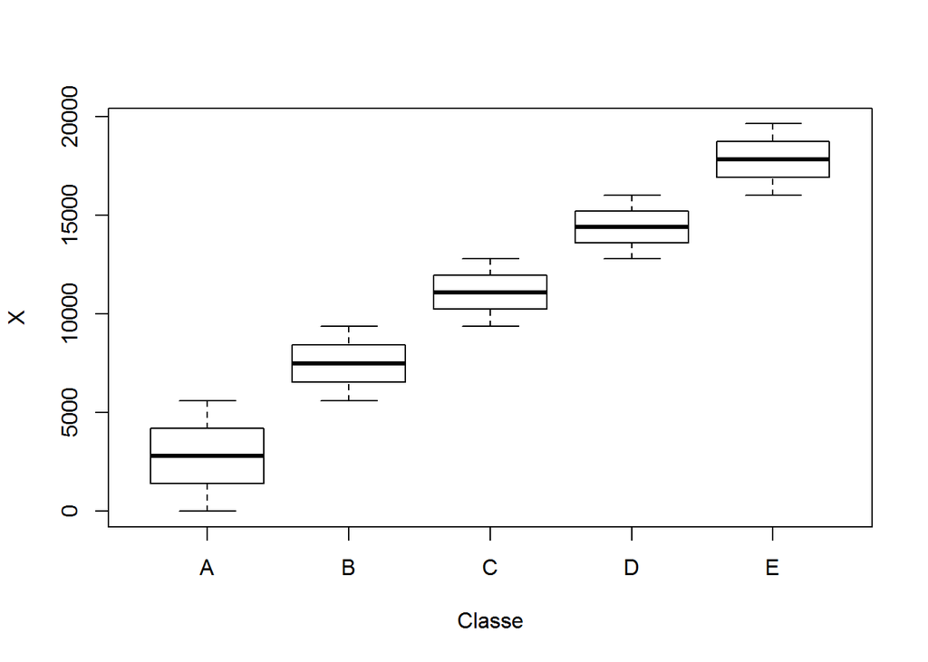

## Appendix *Figure A1 - Model Predictors*

```
##  [1] "roll_belt"            "pitch_belt"           "yaw_belt"
##  [4] "total_accel_belt"     "gyros_belt_x"         "gyros_belt_y"
##  [7] "gyros_belt_z"         "accel_belt_x"         "accel_belt_y"
## [10] "accel_belt_z"         "magnet_belt_x"        "magnet_belt_y"
## [13] "magnet_belt_z"        "roll_arm"             "pitch_arm"
## [16] "yaw_arm"              "total_accel_arm"      "gyros_arm_x"
## [19] "gyros_arm_y"          "gyros_arm_z"          "accel_arm_x"
## [22] "accel_arm_y"          "accel_arm_z"          "magnet_arm_x"
## [25] "magnet_arm_y"         "magnet_arm_z"         "roll_dumbbell"
## [28] "pitch_dumbbell"       "yaw_dumbbell"         "total_accel_dumbbell"
## [31] "gyros_dumbbell_x"     "gyros_dumbbell_y"     "gyros_dumbbell_z"
## [34] "accel_dumbbell_x"     "accel_dumbbell_y"     "accel_dumbbell_z"
## [37] "magnet_dumbbell_x"    "magnet_dumbbell_y"    "magnet_dumbbell_z"
## [40] "roll_forearm"         "pitch_forearm"        "yaw_forearm"
## [43] "total_accel_forearm"  "gyros_forearm_x"      "gyros_forearm_y"
## [46] "gyros_forearm_z"      "accel_forearm_x"      "accel_forearm_y"
## [49] "accel_forearm_z"      "magnet_forearm_x"     "magnet_forearm_y"
## [52] "magnet_forearm_z"
```